# T2

### TCX3212 Predictive Analytics

### Tutorial/Lab 2

Learning Objectives

- Manipulate data in Python
- Generate charts/graphics on Python
- © 2025 Samantha Sow Jin Sze. National University of Singapore. Unauthorized reproduction or distribution is prohibited.

```python
# In JupyterLab, first navigate to the directory containing College.csv
import os
#os.chdir('')  # Replace with your actual path
```

#### Question 1

Q1 Download BirdFluCases.txt onto your desktop or any directory. Before reading the data, it can be viewed in Excel or a text editor.

```python
import pandas as pd

df = pd.read_csv('BirdFluCases.txt', sep="\t")
df.head()
```

|  | Year | Azerbaijan | Bangladesh | Cambodia | China | Djibouti | Egypt | Indonesia | Iraq | LaoPDR | Myanmar | Nigeria | Pakistan | Thailand | Turkey | VietNam |
| --- | --- | --- | --- | --- | --- | --- | --- | --- | --- | --- | --- | --- | --- | --- | --- | --- |
| 0 | 2003 | 0 | 0 | 0 | 1 | 0 | 0 | 0 | 0 | 0 | 0 | 0 | 0 | 0 | 0 | 3 |
| 1 | 2004 | 0 | 0 | 0 | 0 | 0 | 0 | 0 | 0 | 0 | 0 | 0 | 0 | 17 | 0 | 29 |
| 2 | 2005 | 0 | 0 | 4 | 8 | 0 | 0 | 20 | 0 | 0 | 0 | 0 | 0 | 5 | 0 | 61 |
| 3 | 2006 | 8 | 0 | 2 | 13 | 1 | 18 | 55 | 3 | 0 | 0 | 0 | 0 | 3 | 12 | 0 |
| 4 | 2007 | 0 | 0 | 1 | 5 | 0 | 25 | 42 | 0 | 2 | 1 | 1 | 3 | 0 | 0 | 8 |

a) Compute the case counts of bird flu cases for each year

```python
print(df.columns)

# cases_per_year = df.groupby('Year')['Cases'].sum()
# print(cases_per_year)

df['CasesCount'] = df.drop('Year', axis=1).sum(axis=1)

cases_per_year = df[['Year', 'CasesCount']]
print(cases_per_year)
```

```
Index(['Year', 'Azerbaijan', 'Bangladesh', 'Cambodia', 'China', 'Djibouti',
       'Egypt', 'Indonesia', 'Iraq', 'LaoPDR', 'Myanmar', 'Nigeria',
       'Pakistan', 'Thailand', 'Turkey', 'VietNam'],
      dtype='object')
   Year  CasesCount
0  2003           4
1  2004          46
2  2005          98
3  2006         115
4  2007          88
5  2008          34
```

b) Similarly, compute the total number of bird flu deaths per year. Then, merge the results from (a) and (b) into a single DataFrame using an inner join, ensuring each row represents a unique year with both cases and deaths.

```python
df2 = pd.read_csv('BirdFluDeaths.txt', sep="\t")
df2.head()

df2['DeathCases'] = df2.drop('Year', axis=1).sum(axis=1)

deaths_per_year = df2[['Year', 'DeathCases']]
print(deaths_per_year)

bird_flu_merged = pd.merge(cases_per_year, deaths_per_year, how='inner', on='Year')
print(bird_flu_merged)
```

```
   Year  DeathCases
0  2003           4
1  2004          32
2  2005          43
3  2006          79
4  2007          59
5  2008          26
   Year  CasesCount  DeathCases
0  2003           4           4
1  2004          46          32
2  2005          98          43
3  2006         115          79
4  2007          88          59
5  2008          34          26
```

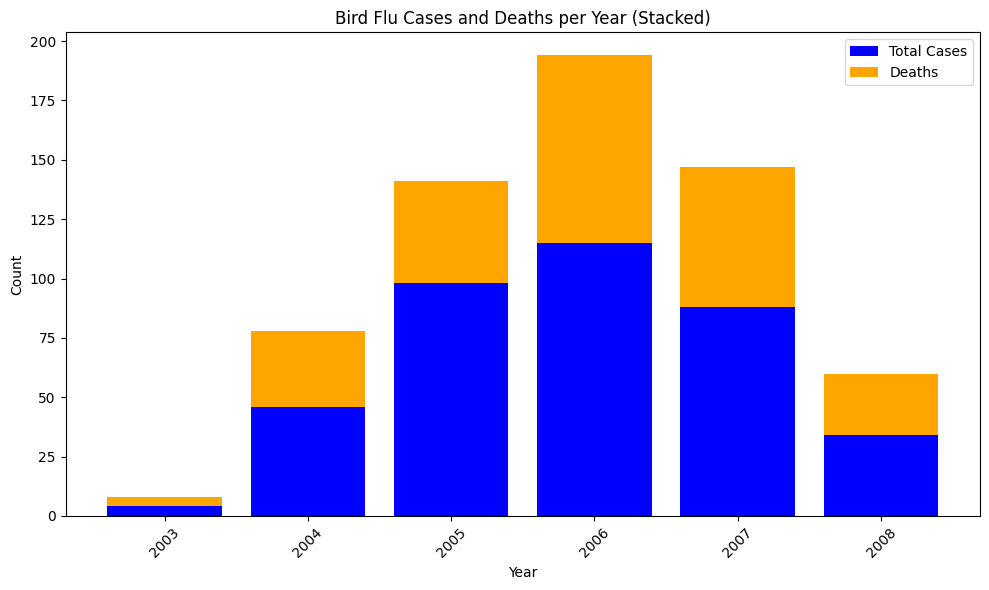

```python
import matplotlib.pyplot as plt

# Create stacked bar chart
years = bird_flu_merged['Year']
cases = bird_flu_merged['CasesCount']
deaths = bird_flu_merged['DeathCases']

plt.figure(figsize=(10, 6))
plt.bar(years, cases, label='Total Cases', color='blue')
plt.bar(years, deaths, bottom=cases, label='Deaths', color='orange')

plt.xlabel('Year')
plt.ylabel('Count')
plt.title('Bird Flu Cases and Deaths per Year (Stacked)')
plt.legend()
plt.xticks(years, rotation=45)
plt.tight_layout()
plt.show()
```

d) Modify the chart to a clustered (side-by-side) bar chart to show deaths alongside cases, improving interpretability while correctly reflecting that deaths are a subset of cases.

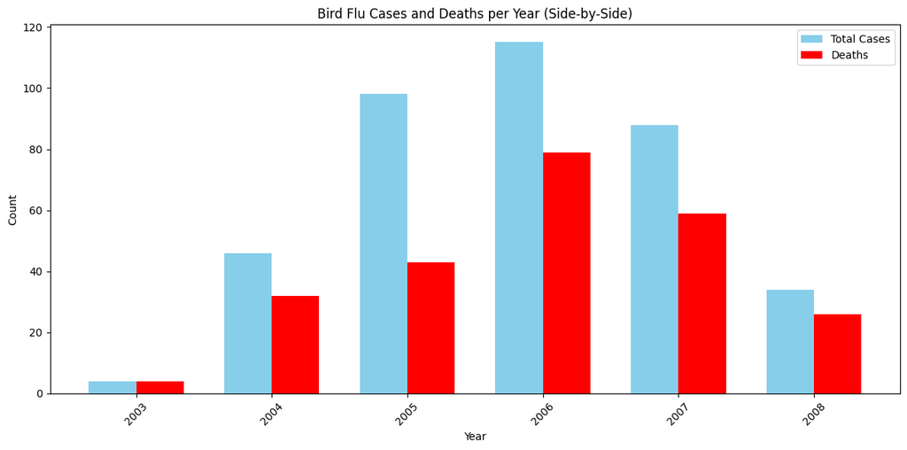

```python
import numpy as np
import matplotlib.pyplot as plt

x = np.arange(len(bird_flu_merged['Year']))

# positions
width = 0.35

# Get data
years = bird_flu_merged['Year']
cases = bird_flu_merged['CasesCount']
deaths = bird_flu_merged['DeathCases']

# Create side-by-side bars
plt.figure(figsize=(12, 6))
plt.bar(x - width/2, cases, width, label='Total Cases', color='skyblue')
plt.bar(x + width/2, deaths, width, label='Deaths', color='red')

plt.xlabel('Year')
plt.ylabel('Count')
plt.title('Bird Flu Cases and Deaths per Year (Side-by-Side)')
plt.xticks(x, labels=years, rotation=45)
plt.legend()
plt.tight_layout()
plt.show()
```

#### Question 2

Download College.csv onto your desktop or any directory. Before reading the data, it can be viewed in Excel or a text editor. Open JupyterLab and change the working directory to the path where you have placed College.csv. Use the pd.read_csv() function to read the data into a variable college in jupyter notebook.

```python
college_df = pd.read_csv('College.csv')
college_df.head()
```

|  | Unnamed: 0 | Private | Apps | Accept | Enroll | Top10perc | Top25perc | F.Undergrad | P.Undergrad | Outstate | Room.Board | Books | Personal | PhD | Terminal | S.F.Ratio | perc.alumni | Expend | Grad.Rate |
| --- | --- | --- | --- | --- | --- | --- | --- | --- | --- | --- | --- | --- | --- | --- | --- | --- | --- | --- | --- |
| 0 | Abilene Christian University | Yes | 1660 | 1232 | 721 | 23 | 52 | 2885 | 537 | 7440 | 3300 | 450 | 2200 | 70 | 78 | 18.1 | 12 | 7041 | 60 |
| 1 | Adelphi University | Yes | 2186 | 1924 | 512 | 16 | 29 | 2683 | 1227 | 12280 | 6450 | 750 | 1500 | 29 | 30 | 12.2 | 16 | 10527 | 56 |
| 2 | Adrian College | Yes | 1428 | 1097 | 336 | 22 | 50 | 1036 | 99 | 11250 | 3750 | 400 | 1165 | 53 | 66 | 12.9 | 30 | 8735 | 54 |
| 3 | Agnes Scott College | Yes | 417 | 349 | 137 | 60 | 89 | 510 | 63 | 12960 | 5450 | 450 | 875 | 92 | 97 | 7.7 | 37 | 19016 | 59 |
| 4 | Alaska Pacific University | Yes | 193 | 146 | 55 | 16 | 44 | 249 | 869 | 7560 | 4120 | 800 | 1500 | 76 | 72 | 11.9 | 2 | 10922 | 15 |

a) Use the describe() function to produce a numerical summary of the variables in the data set.

```python
college_df.describe()
```

|  | Apps | Accept | Enroll | Top10perc | Top25perc | F.Undergrad | P.Undergrad | Outstate | Room.Board | Books | Personal | PhD | Terminal | S.F.Ratio | perc.alumni | Expend | Grad.Rate |
| --- | --- | --- | --- | --- | --- | --- | --- | --- | --- | --- | --- | --- | --- | --- | --- | --- | --- |
| count | 777.000000 | 777.000000 | 777.000000 | 777.000000 | 777.000000 | 777.000000 | 777.000000 | 777.000000 | 777.000000 | 777.000000 | 777.000000 | 777.000000 | 777.000000 | 777.000000 | 777.000000 | 777.000000 | 777.00000 |
| mean | 3001.638353 | 2018.804376 | 779.972973 | 27.558559 | 55.796654 | 3699.907336 | 855.298584 | 10440.669241 | 4357.526384 | 549.380952 | 1340.642214 | 72.660232 | 79.702703 | 14.089704 | 22.743887 | 9660.171171 | 65.46332 |
| std | 3870.201484 | 2451.113971 | 929.176190 | 17.640364 | 19.804778 | 4850.420531 | 1522.431887 | 4023.016484 | 1096.696416 | 165.105360 | 677.071454 | 16.328155 | 14.722359 | 3.958349 | 12.391801 | 5221.768440 | 17.17771 |
| min | 81.000000 | 72.000000 | 35.000000 | 1.000000 | 9.000000 | 139.000000 | 1.000000 | 2340.000000 | 1780.000000 | 96.000000 | 250.000000 | 8.000000 | 24.000000 | 2.500000 | 0.000000 | 3186.000000 | 10.00000 |
| 25% | 776.000000 | 604.000000 | 242.000000 | 15.000000 | 41.000000 | 992.000000 | 95.000000 | 7320.000000 | 3597.000000 | 470.000000 | 850.000000 | 62.000000 | 71.000000 | 11.500000 | 13.000000 | 6751.000000 | 53.00000 |
| 50% | 1558.000000 | 1110.000000 | 434.000000 | 23.000000 | 54.000000 | 1707.000000 | 353.000000 | 9990.000000 | 4200.000000 | 500.000000 | 1200.000000 | 75.000000 | 82.000000 | 13.600000 | 21.000000 | 8377.000000 | 65.00000 |
| 75% | 3624.000000 | 2424.000000 | 902.000000 | 35.000000 | 69.000000 | 4005.000000 | 967.000000 | 12925.000000 | 5050.000000 | 600.000000 | 1700.000000 | 85.000000 | 92.000000 | 16.500000 | 31.000000 | 10830.000000 | 78.00000 |
| max | 48094.000000 | 26330.000000 | 6392.000000 | 96.000000 | 100.000000 | 31643.000000 | 21836.000000 | 21700.000000 | 8124.000000 | 2340.000000 | 6800.000000 | 103.000000 | 100.000000 | 39.800000 | 64.000000 | 56233.000000 | 118.00000 |

b) Create a scatterplot matrix for the following variables using Matplotlib: Apps, Accept, Enroll, Grad.Rate.

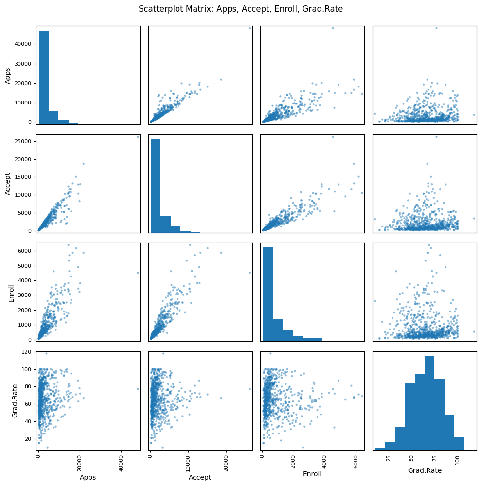

```python
from pandas.plotting import scatter_matrix
import matplotlib.pyplot as plt

# Select the variables for the scatterplot matrix
selected_vars = ['Apps', 'Accept', 'Enroll', 'Grad.Rate']

# Create scatterplot matrix
scatter_matrix(college_df[selected_vars],
                           figsize=(10, 10),
                           diagonal='hist')

plt.suptitle('Scatterplot Matrix: Apps, Accept, Enroll, Grad.Rate', y=0.995)
plt.tight_layout()
plt.show()
```

c) Generate the same scatterplot matrix as in (b) but differentiate between Private and Non-private University using different colors.

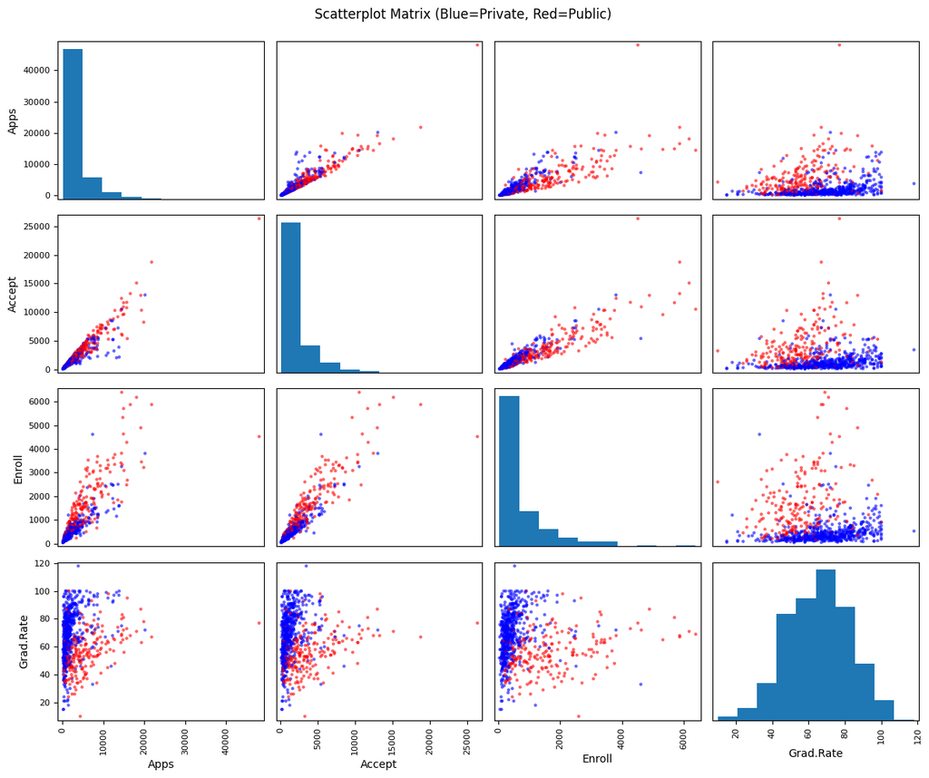

```python
from pandas.plotting import scatter_matrix
import matplotlib.pyplot as plt

# Select the variables for the scatterplot matrix
selected_vars = ['Apps', 'Accept', 'Enroll', 'Grad.Rate']

# Create color mapping for Private column
color_map = {'Yes': 'blue', 'No': 'red'}
colors = college_df['Private'].map(color_map)

# Create scatterplot matrix with color differentiation
scatter_matrix(college_df[selected_vars],
               figsize=(12, 10),
               diagonal='hist',
               color=colors,
               alpha=0.6)

plt.suptitle('Scatterplot Matrix (Blue=Private, Red=Public)', y=0.995)
plt.tight_layout()
plt.show()
```

d) Use the matplotlib.pyplot.boxplot()function to create side-by-side boxplots to compare the number of applications (Apps) for private and public colleges (Private). Label your axes and add a title for your plot.

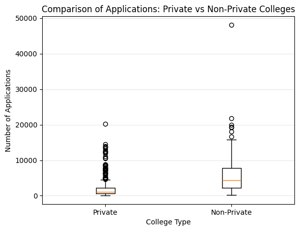

```python
import matplotlib.pyplot as plt
import numpy as np

# Use np.where to differentiate Private and Public colleges
private_apps = college_df[np.where(college_df['Private'] == 'Yes', True, False)]['Apps']
non_private_apps = college_df[np.where(college_df['Private'] == 'No', True, False)]['Apps']

# Create side-by-side boxplots
plt.boxplot([private_apps, non_private_apps], labels=['Private', 'Non-Private'], vert=True)

plt.xlabel('College Type')
plt.ylabel('Number of Applications')
plt.title('Comparison of Applications: Private vs Non-Private Colleges')
plt.grid(axis='y', alpha=0.3)
plt.show()
```

e) Produce a scatterplot of Top10perc (percentage of new students from the top 10% of their high school) against Grad.Rate (graduation rate) Use different colors to represent different percentages in Top10perc (<=30, <=50, <=70, >70).

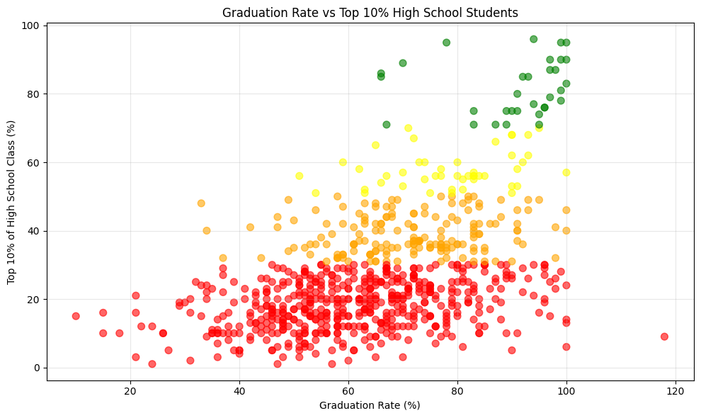

```python
import matplotlib.pyplot as plt

def top10_color(val):
    if val <= 30:
        return 'red'
    elif val <= 50:
        return 'orange'
    elif val <= 70:
        return 'yellow'
    else:
        return 'green'

colours = college_df['Top10perc'].apply(top10_color)

# Create scatterplot
plt.figure(figsize=(10, 6))
plt.scatter(college_df['Grad.Rate'],college_df['Top10perc'], c=colours, alpha=0.6, s=50)

plt.xlabel('Graduation Rate (%)')
plt.ylabel('Top 10% of High School Class (%)')
plt.title('Graduation Rate vs Top 10% High School Students')

plt.grid(alpha=0.3)
plt.tight_layout()
plt.show()
```

f) Use the matplotlib.pyplot.hist() function to generate a histogram of Top10perc. Add the same color-coding scheme as (e)

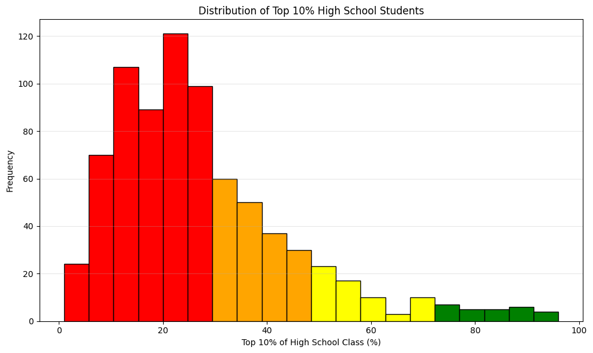

```python
import matplotlib.pyplot as plt

# Create histogram
plt.figure(figsize=(10, 6))
n, bins, patches = plt.hist(college_df['Top10perc'], bins=20, edgecolor='black')

# Color each bar based on its bin center using the top10_color function
for patch in patches:
    top = patch.get_x()
    width = patch.get_width()
    bin_center = top + width / 2
    patch.set_facecolor(top10_color(bin_center))

plt.xlabel('Top 10% of High School Class (%)')
plt.ylabel('Frequency')
plt.title('Distribution of Top 10% High School Students')
plt.grid(axis='y', alpha=0.3)
plt.tight_layout()
plt.show()
```